# Assignment 1 - College Data - Descriptive Analysis

Philipp Markopulos

h12030674@wu.ac.at

October 20th, 2021

# Preparation

## Load libraries

```r
library("ISLR")
library("stats")
library("tidyverse")
library("ggplot2")
library("caret")
library("ggbeeswarm")
library("patchwork")
library("Metrics")
library("FNN")
```

## Load data

```r
data("College")
```

# Task 1

## Descriptive statistics:

### Summary

We are dealing with a statistics for a number of US colleges from the 1995 issue of U.S. News and World Report. This data contains that year’s number of applications to those colleges, as well as acceptance and enrollment numbers. Each line also contains some underlying attributes of the colleges like tuition or data on the faculty staff.

### Structure of the data

```r
str(College)
```

```
## 'data.frame':    777 obs. of  18 variables:
##  $ Private    : Factor w/ 2 levels "No","Yes": 2 2 2 2 2 2 2 2 2 2 ...
##  $ Apps       : num  1660 2186 1428 417 193 ...
##  $ Accept     : num  1232 1924 1097 349 146 ...
##  $ Enroll     : num  721 512 336 137 55 158 103 489 227 172 ...
##  $ Top10perc  : num  23 16 22 60 16 38 17 37 30 21 ...
##  $ Top25perc  : num  52 29 50 89 44 62 45 68 63 44 ...
##  $ F.Undergrad: num  2885 2683 1036 510 249 ...
##  $ P.Undergrad: num  537 1227 99 63 869 ...
##  $ Outstate   : num  7440 12280 11250 12960 7560 ...
##  $ Room.Board : num  3300 6450 3750 5450 4120 ...
##  $ Books      : num  450 750 400 450 800 500 500 450 300 660 ...
##  $ Personal   : num  2200 1500 1165 875 1500 ...
##  $ PhD        : num  70 29 53 92 76 67 90 89 79 40 ...
##  $ Terminal   : num  78 30 66 97 72 73 93 100 84 41 ...
##  $ S.F.Ratio  : num  18.1 12.2 12.9 7.7 11.9 9.4 11.5 13.7 11.3 11.5 ...
##  $ perc.alumni: num  12 16 30 37 2 11 26 37 23 15 ...
##  $ Expend     : num  7041 10527 8735 19016 10922 ...
##  $ Grad.Rate  : num  60 56 54 59 15 55 63 73 80 52 ...
```

There are 777 observations of 18 variables. All variables except `Private`, which is a factor with two levels, are numeric.

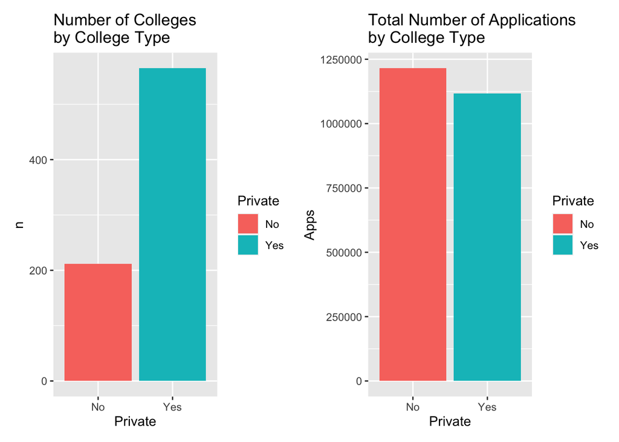

```r
College %>%
    group_by(Private) %>%
    summarize(n = n()) %>%
    ggplot() +
    geom_col(
        aes(
            Private,
            n,
            fill = Private
        )
    ) +
    labs(
        title = "Number of Colleges\nby College Type"
    ) +
    ggplot(College) +
    geom_col(
        aes(
            Private,
            Apps,
            fill = Private
        )
    ) +
    labs(
        title = "Total Number of Applications\nby College Type"
    )
```

It is also evident that the data contains far more private than public colleges. These private colleges, however, seem to have fewer applications on average.

```r
summary(College)
```

```
##  Private        Apps           Accept          Enroll       Top10perc
##  No :212   Min.   :   81   Min.   :   72   Min.   :  35   Min.   : 1.00
##  Yes:565   1st Qu.:  776   1st Qu.:  604   1st Qu.: 242   1st Qu.:15.00
##            Median : 1558   Median : 1110   Median : 434   Median :23.00
##            Mean   : 3002   Mean   : 2019   Mean   : 780   Mean   :27.56
##            3rd Qu.: 3624   3rd Qu.: 2424   3rd Qu.: 902   3rd Qu.:35.00
##            Max.   :48094   Max.   :26330   Max.   :6392   Max.   :96.00
##    Top25perc      F.Undergrad     P.Undergrad         Outstate
##  Min.   :  9.0   Min.   :  139   Min.   :    1.0   Min.   : 2340
##  1st Qu.: 41.0   1st Qu.:  992   1st Qu.:   95.0   1st Qu.: 7320
##  Median : 54.0   Median : 1707   Median :  353.0   Median : 9990
##  Mean   : 55.8   Mean   : 3700   Mean   :  855.3   Mean   :10441
##  3rd Qu.: 69.0   3rd Qu.: 4005   3rd Qu.:  967.0   3rd Qu.:12925
##  Max.   :100.0   Max.   :31643   Max.   :21836.0   Max.   :21700
##    Room.Board       Books           Personal         PhD
##  Min.   :1780   Min.   :  96.0   Min.   : 250   Min.   :  8.00
##  1st Qu.:3597   1st Qu.: 470.0   1st Qu.: 850   1st Qu.: 62.00
##  Median :4200   Median : 500.0   Median :1200   Median : 75.00
##  Mean   :4358   Mean   : 549.4   Mean   :1341   Mean   : 72.66
##  3rd Qu.:5050   3rd Qu.: 600.0   3rd Qu.:1700   3rd Qu.: 85.00
##  Max.   :8124   Max.   :2340.0   Max.   :6800   Max.   :103.00
##     Terminal       S.F.Ratio      perc.alumni        Expend
##  Min.   : 24.0   Min.   : 2.50   Min.   : 0.00   Min.   : 3186
##  1st Qu.: 71.0   1st Qu.:11.50   1st Qu.:13.00   1st Qu.: 6751
##  Median : 82.0   Median :13.60   Median :21.00   Median : 8377
##  Mean   : 79.7   Mean   :14.09   Mean   :22.74   Mean   : 9660
##  3rd Qu.: 92.0   3rd Qu.:16.50   3rd Qu.:31.00   3rd Qu.:10830
##  Max.   :100.0   Max.   :39.80   Max.   :64.00   Max.   :56233
##    Grad.Rate
##  Min.   : 10.00
##  1st Qu.: 53.00
##  Median : 65.00
##  Mean   : 65.46
##  3rd Qu.: 78.00
##  Max.   :118.00
```

Some variables seem to have suspicious data points:

- `PhD`, which is the ratio of PhD holders in teaching staff, has a max value of 103.
- `Grad.Rate`, which is the graduation rate, has a max value of 118.

Those values need to be dealt with by either removal or truncation.

There seem to be no other missing or invalid values in the data.

```r
moments::skewness(College[,2:18]) %>% abs() %>% sort(decreasing = TRUE)
```

```
## P.Undergrad        Apps       Books      Expend      Accept      Enroll
##   5.6813582   3.7165574   3.4782933   3.4526399   3.4111259   2.6852679
## F.Undergrad    Personal   Top10perc    Terminal         PhD   S.F.Ratio
##   2.6054157   1.7391308   1.4104871   0.8149652   0.7666864   0.6661462
## perc.alumni    Outstate  Room.Board   Top25perc   Grad.Rate
##   0.6057190   0.5082943   0.4764335   0.2588394   0.1135575
```

This suggests that there are large differences between the observations.

### Correlation among numeric variables

```r
cor_test_result <- cor(College[,-1]) %>% as_tibble()

# At least moderately correlated variables
cor_test_result_low <- cor_test_result %>%
  mutate(
    across(
      everything(),
        ~ifelse(
          . < .25,
          NA_real_,
          .
        )
      )
    )
cor_test_result_low
```

```
## # A tibble: 17 × 17
##      Apps Accept Enroll Top10perc Top25perc F.Undergrad P.Undergrad Outstate
##     <dbl>  <dbl>  <dbl>     <dbl>     <dbl>       <dbl>       <dbl>    <dbl>
##  1  1      0.943  0.847     0.339     0.352       0.814       0.398   NA
##  2  0.943  1      0.912    NA        NA           0.874       0.441   NA
##  3  0.847  0.912  1        NA        NA           0.965       0.513   NA
##  4  0.339 NA     NA         1         0.892      NA          NA        0.562
##  5  0.352 NA     NA         0.892     1          NA          NA        0.489
##  6  0.814  0.874  0.965    NA        NA           1           0.571   NA
##  7  0.398  0.441  0.513    NA        NA           0.571       1       NA
##  8 NA     NA     NA         0.562     0.489      NA          NA        1
##  9 NA     NA     NA         0.371     0.331      NA          NA        0.654
## 10 NA     NA     NA        NA        NA          NA          NA       NA
## 11 NA     NA      0.281    NA        NA           0.317       0.320   NA
## 12  0.391  0.356  0.331     0.532     0.546       0.318      NA        0.383
## 13  0.369  0.338  0.308     0.491     0.525       0.300      NA        0.408
## 14 NA     NA     NA        NA        NA           0.280      NA       NA
## 15 NA     NA     NA         0.455     0.418      NA          NA        0.566
## 16  0.260 NA     NA         0.661     0.527      NA          NA        0.673
## 17 NA     NA     NA         0.495     0.477      NA          NA        0.571
## # … with 9 more variables: Room.Board <dbl>, Books <dbl>, Personal <dbl>,
## #   PhD <dbl>, Terminal <dbl>, S.F.Ratio <dbl>, perc.alumni <dbl>,
## #   Expend <dbl>, Grad.Rate <dbl>
```

We can see that many variables are at least moderately correlated.

```r
# Highly correlated variables
cor_test_result_high <- cor_test_result %>%
  mutate(
    across(
      everything(),
      ~ifelse(
        . < .75,
        NA_real_,
        .
      )
    )
  )
cor_test_result_high
```

```
## # A tibble: 17 × 17
##      Apps Accept Enroll Top10perc Top25perc F.Undergrad P.Undergrad Outstate
##     <dbl>  <dbl>  <dbl>     <dbl>     <dbl>       <dbl>       <dbl>    <dbl>
##  1  1      0.943  0.847    NA        NA           0.814          NA       NA
##  2  0.943  1      0.912    NA        NA           0.874          NA       NA
##  3  0.847  0.912  1        NA        NA           0.965          NA       NA
##  4 NA     NA     NA         1         0.892      NA              NA       NA
##  5 NA     NA     NA         0.892     1          NA              NA       NA
##  6  0.814  0.874  0.965    NA        NA           1              NA       NA
##  7 NA     NA     NA        NA        NA          NA               1       NA
##  8 NA     NA     NA        NA        NA          NA              NA        1
##  9 NA     NA     NA        NA        NA          NA              NA       NA
## 10 NA     NA     NA        NA        NA          NA              NA       NA
## 11 NA     NA     NA        NA        NA          NA              NA       NA
## 12 NA     NA     NA        NA        NA          NA              NA       NA
## 13 NA     NA     NA        NA        NA          NA              NA       NA
## 14 NA     NA     NA        NA        NA          NA              NA       NA
## 15 NA     NA     NA        NA        NA          NA              NA       NA
## 16 NA     NA     NA        NA        NA          NA              NA       NA
## 17 NA     NA     NA        NA        NA          NA              NA       NA
## # … with 9 more variables: Room.Board <dbl>, Books <dbl>, Personal <dbl>,
## #   PhD <dbl>, Terminal <dbl>, S.F.Ratio <dbl>, perc.alumni <dbl>,
## #   Expend <dbl>, Grad.Rate <dbl>
```

Some variables are extremely correlated and probably should be investigated further.

## Data visualization

### Apps and Private

[figure not shown]

```r
ggplot() +
    geom_quasirandom(
        data = College,
        aes(
            x = 1,
            y = Apps,
            color = Private
        ),
        size = 0.5
    )  +
    labs(
        title = "College type vs. Applications",
        subtitle = "With log10 transformation, colored by college type, with regression line"
    ) +
    theme(
        axis.title.x = element_blank(),
        axis.ticks.x = element_blank(),
        axis.text.x = element_blank()
    )  +
    labs(
      title = "Number of Aplications by College Type"
    )
```

From the figure it can be assumed that private colleges more often have fewer applications than public colleges.

[figure not shown]

```r
ggplot() +
    geom_quasirandom(
        data = College,
        aes(
            x = Private,
            y = Apps,
            color = Private
        ),
        size = 0.5
    ) +
    geom_boxplot(
        data = College,
        aes(
            x = Private,
            y = Apps
        ),
        alpha = 0.5,
        outlier.color = NA
    )  +
    labs(
      title = "College type vs. Applications",
      subtitle = "With log10 transformation, colored by college type, with regression line"
    )
```

```r
quantile(College$Apps[College$Private == "Yes"])
```

```
##    0%   25%   50%   75%  100%
##    81   619  1133  2186 20192
```

```r
quantile(College$Apps[College$Private == "No"])
```

```
##       0%      25%      50%      75%     100%
##   233.00  2190.75  4307.00  7722.50 48094.00
```

The assumption can be verified by looking at the boxplots and quantiles. The data shows that there is a potentially significant difference between colleges that are private vs. public colleges:

- The 25th percentile of applications of public colleges is higher than the 75th percentile of the number of applications of private colleges.
- Public colleges contain the highest outlier at around 48,000 applications.
- The value band of 25th to 75th percentiles is much smaller for private colleges than for public ones.
- However, private colleges contain a large number of outliers with around 5,000 to 15,000 applications beyond 1.5*IQR (beyond the end of the top boxplot whisker).

### Apps and Accept

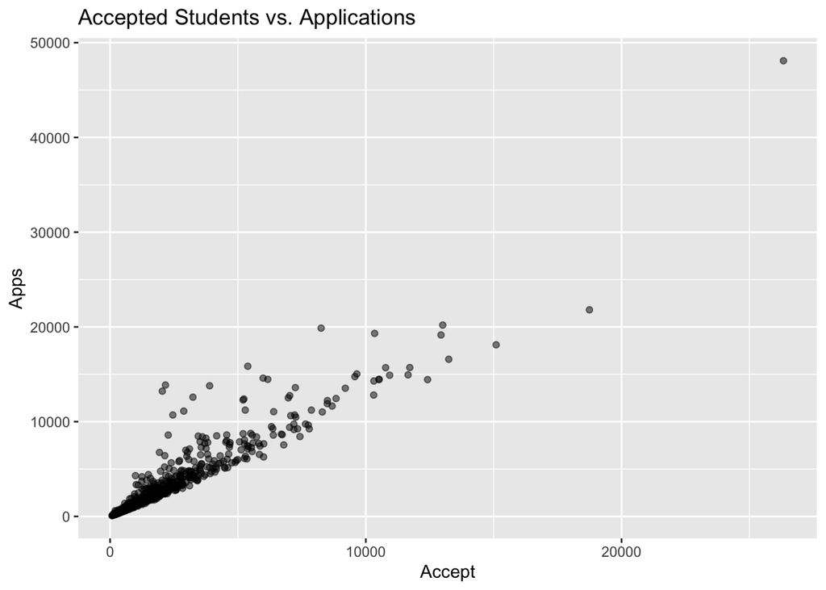

```r
ggplot() +
    geom_point(
        data = College,
        aes(
            x = Accept,
            y = Apps
        ),
        alpha = 0.5
    ) +
    labs(
      title = "Accepted Students vs. Applications"
    )
```

The first look at the plot suggest a linear relationship.

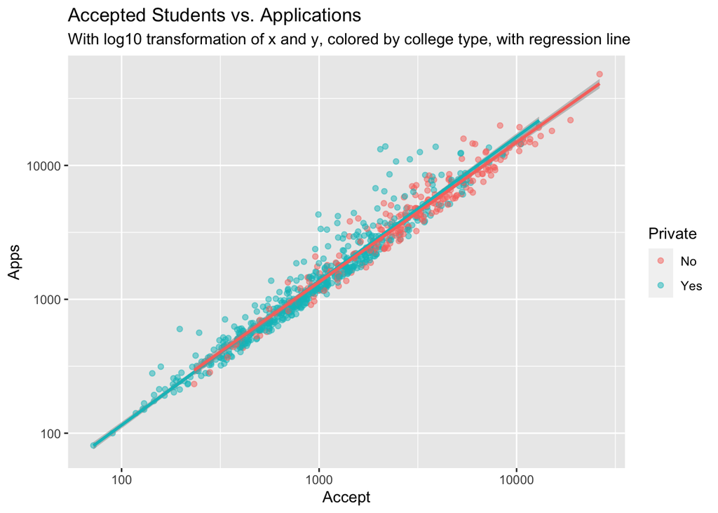

```r
ggplot() +
    geom_point(
        data = College,
        aes(
            x = Accept,
            y = Apps,
            color = Private
        ),
        alpha = 0.5
    ) +
    geom_smooth(
        data = College[College$Private == "Yes", ],
        aes(
            x = Accept,
            y = Apps
        ),
        color = "#00BFC4",
        alpha = 0.5,
        method = "lm"
    ) +
    geom_smooth(
        data = College[College$Private == "No", ],
        aes(
            x = Accept,
            y = Apps
        ),
        color = "#F8766D",
        alpha = 0.5,
        method = "lm"
    ) +
    scale_x_log10() +
    scale_y_log10() +
    labs(
      title = "Accepted Students vs. Applications",
      subtitle = "With log10 transformation of x and y, colored by college type, with regression line"
    )
```

This can also be verified by closer visual examination. Logically, it also makes sense that, theoretically, only colleges with a large number of applications can have a large number of accepts.

### Apps and PhD

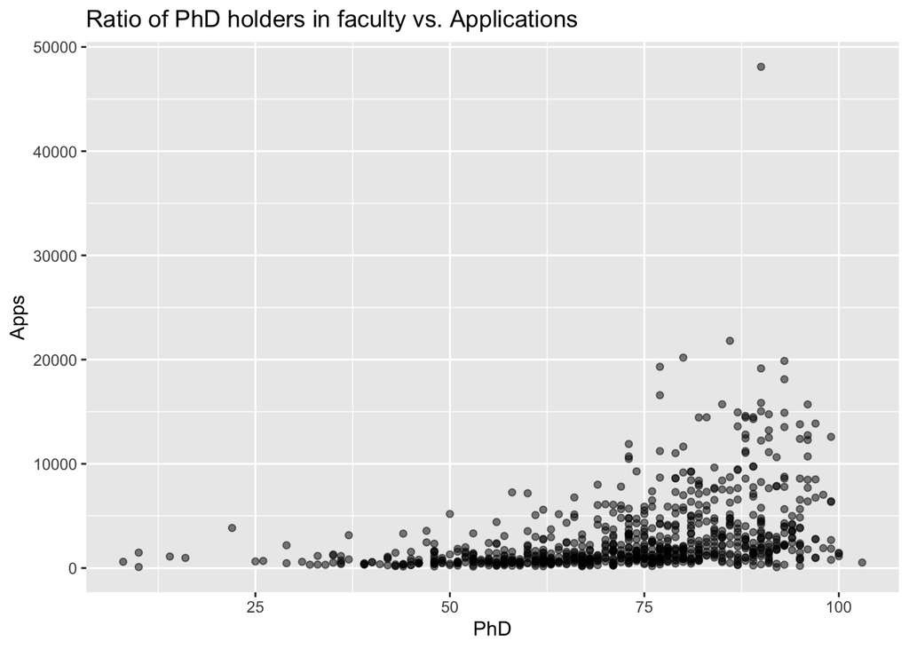

```r
ggplot() +
    geom_point(
        data = College,
        aes(
            x = PhD,
            y = Apps
        ),
        alpha = 0.5
    ) +
    labs(
      title = "Ratio of PhD holders in faculty vs. Applications"
    )
```

A first look suggests a slightly linear or exponential relationship.

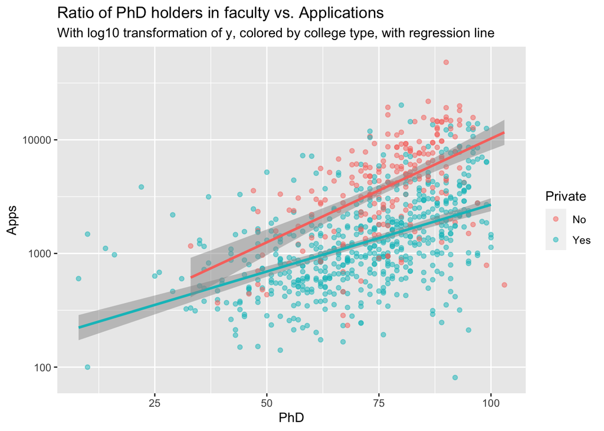

```r
ggplot() +
    geom_point(
        data = College,
        aes(
            x = PhD,
            y = Apps,
            color = Private
        ),
        alpha = 0.5
    ) +
    geom_smooth(
        data = College[College$Private == "Yes", ],
        aes(
            x = PhD,
            y = Apps
        ),
        color = "#00BFC4",
        alpha = 0.5,
        method = "lm"
    ) +
    geom_smooth(
        data = College[College$Private == "No", ],
        aes(
            x = PhD,
            y = Apps
        ),
        color = "#F8766D",
        alpha = 0.5,
        method = "lm"
    ) +
    scale_y_log10() +
    labs(
      title = "Ratio of PhD holders in faculty vs. Applications",
      subtitle = "With log10 transformation of y, colored by college type, with regression line"
    )
```

Closer examination shows that there are differences in the slope of the curve between private and public colleges.

### Apps and S.F.Ratio

[figure not shown]

```r
ggplot() +
    geom_point(
        data = College,
        aes(
            x = S.F.Ratio,
            y = Accept
        ),
        alpha = 0.5
    ) +
    labs(
      title = "Ratio of Students-to-Faculty-Members vs. Applications",
      subtitle = "With log10 transformation of y, colored by college type, with regression line"
    )
```

From a first examination, no evident relationship is visible.

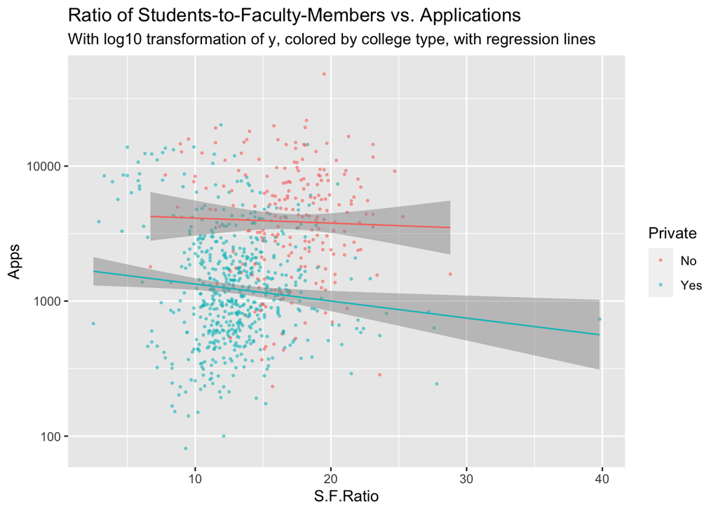

```r
ggplot() +
    geom_point(
        data = College,
        aes(
            x = S.F.Ratio,
            y = Apps,
            color = Private
        ),
        alpha = 0.5,
        size = 0.5
    ) +
    geom_smooth(
        data = College[College$Private == "Yes", ],
        aes(
            x = S.F.Ratio,
            y = Apps
        ),
        color = "#00BFC4",
        alpha = 0.5,
        size = 0.5,
        method = "lm"
    ) +
    geom_smooth(
        data = College[College$Private == "No", ],
        aes(
            x = S.F.Ratio,
            y = Apps
        ),
        color = "#F8766D",
        alpha = 0.5,
        size = 0.5,
        method = "lm"
    ) +
    scale_y_log10() +
    labs(
      title = "Ratio of Students-to-Faculty-Members vs. Applications",
      subtitle = "With log10 transformation of y, colored by college type, with regression lines"
    )
```

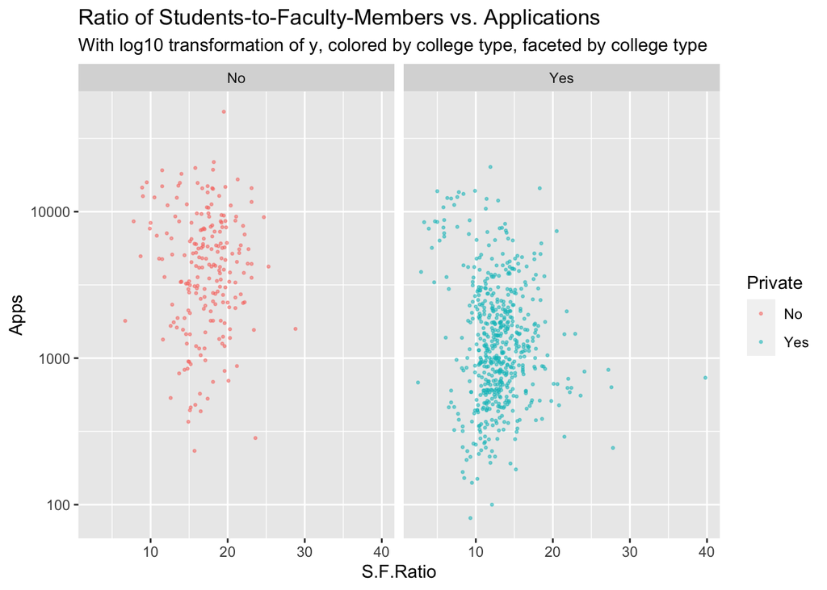

```r
ggplot() +
    geom_point(
        data = College,
        aes(
            x = S.F.Ratio,
            y = Apps,
            color = Private
        ),
        alpha = 0.5,
        size = 0.5
    ) +
    scale_y_log10() +
    facet_grid(. ~ Private) +
    labs(
      title = "Ratio of Students-to-Faculty-Members vs. Applications",
      subtitle = "With log10 transformation of y, colored by college type, faceted by college type"
    )
```

Closer examination show also here the differences between public and private colleges. Furthermore, it could be assumed that the differences related to `S.F.Ratio` could be better captured by a clustering method.

## Preprocessing & further questions

### General problems with the data

As there are some **faulty variable values** in the data, they should be further investigated and treated before model building.

Furthermore, some variables show **large skews** that could negatively impact the model if the residuals follow a non-normal distribution as well.

```r
(max(College$Apps) - quantile(College$Apps, .75)) / IQR(College$Apps) %>% unlist()
```

```
##      75%
## 15.61447
```

The outcome, `Application`, also has outliers far beyond 1.5*IQR (with the highest being more than 15*IQR above Q3) that should be treated for model robustness.

### Problems regarding linear regression

Linear regression assumes the following:

1. **Linearity**: The relationship of predictors and the outcome is linear.
2. **Independence**: Residuals are independent and predictor variables are not codependent.
3. **Homoscedasticity** The variance of residuals is constant.
4. **Normality**: Residuals follow a normal distribution.

```r
shw_test_result <- tibble(
    var_id = 1,
    var_name = "Private",
    statistic = NA_real_,
    p_value = NA_real_
)

for(i in 2:ncol(College)) {
    shw_test <- shapiro.test(College[,i])
    shw_test_result <- bind_rows(
        shw_test_result,
        tibble(
            var_id = i,
            var_name = colnames(College)[i],
            statistic = shw_test$statistic,
            p_value = shw_test$p.value
        )
    )
    rm(shw_test)
}

shw_test_result
```

```
## # A tibble: 18 × 4
##    var_id var_name    statistic   p_value
##     <dbl> <chr>           <dbl>     <dbl>
##  1      1 Private        NA     NA
##  2      2 Apps            0.654  6.82e-37
##  3      3 Accept          0.664  1.72e-36
##  4      4 Enroll          0.678  6.46e-36
##  5      5 Top10perc       0.887  2.45e-23
##  6      6 Top25perc       0.984  1.67e- 7
##  7      7 F.Undergrad     0.656  8.19e-37
##  8      8 P.Undergrad     0.523  2.27e-41
##  9      9 Outstate        0.968  4.18e-12
## 10     10 Room.Board      0.980  6.60e- 9
## 11     11 Books           0.771  1.65e-31
## 12     12 Personal        0.893  8.49e-23
## 13     13 PhD             0.959  7.83e-14
## 14     14 Terminal        0.938  2.04e-17
## 15     15 S.F.Ratio       0.972  4.49e-11
## 16     16 perc.alumni     0.966  1.85e-12
## 17     17 Expend          0.711  1.64e-34
## 18     18 Grad.Rate       0.995  9.42e- 3
```

A Shapiro-Wilk test for normality shows that all **residuals of variable are non-normal*** (the null hypotheses are rejected with a `p-value` below 0.05). Only `Grad.Rate` shows a fairly high test statistic (0.995). This is consistent with the previous assumption that the distribution of the variable `Grad.Rate` is the closest to a normal distribution.

Furthermore, the variables `Accept`, `Enroll`, `Top10perc`, and `Top25perc` are **clearly dependent** on the outcome, i.e. `Apps`.

The visual investigation has also led to the assumption that the impact of the `Private` variable on the outcome might be **non-linear**.

(A test for **heteroscedasticity**, e.g. a Breusch-Pagan test, can only performed after model building.)

We can see already at this stage that most basic principles of linear regression modeling are violated, therefore model building should be problematic.

# Task 2

## Preprocessing

```r
 college_cleaned <- College %>%

    # Prettify variable names
    rename(
        Applications = Apps,
        Enrolled = Enroll,
        Accepted = Accept,
        PercTop10 = Top10perc,
        PercTop25 = Top25perc,
        FTUndergrad = F.Undergrad,
        PTUndergrad = P.Undergrad,
        CostOutstate = Outstate,
        CostRoomBoard = Room.Board,
        CostBooks = Books,
        CostPersonal = Personal,
        ExpenditurePerStudent = Expend,
        GradRate = Grad.Rate,
        PercAlumniDonation = perc.alumni,
        SFRatio = S.F.Ratio,
        PercPhD = PhD,
        PercTerminal = Terminal,
    ) %>%

    # Correct wrong values
    mutate(
      GradRate = ifelse(GradRate > 100, 100, GradRate),
      PercPhD = ifelse(PercPhD > 100, 100, PercPhD)
    ) %>%

    # Remove outliers beyond 1.5*IQR above Q3 or below Q1
    filter(
        !(Applications < quantile(College$Apps, .25) - IQR(College$Apps) * 1.5),
        !(Applications > quantile(College$Apps, .75) + IQR(College$Apps) * 1.5),
    )
```

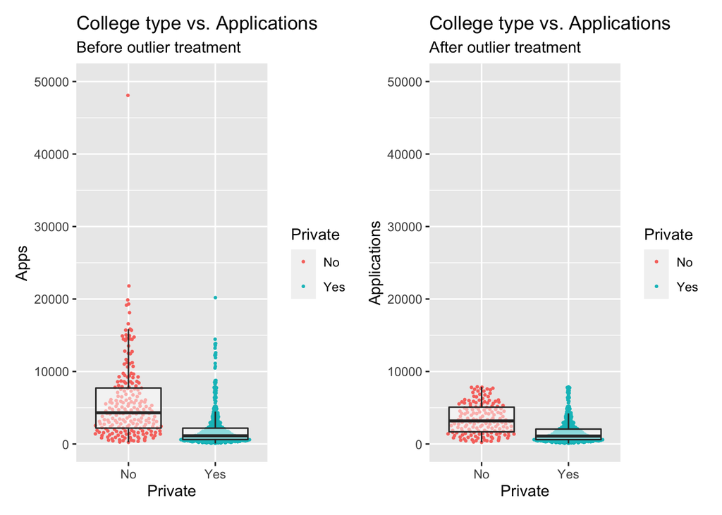

```r
    ggplot() +
    geom_quasirandom(
        data = College,
        aes(
            x = Private,
            y = Apps,
            color = Private
        ),
        size = 0.5
    ) +
    geom_boxplot(
        data = College,
        aes(
            x = Private,
            y = Apps
        ),
        alpha = 0.5,
        outlier.color = NA
    )  +
    labs(
        title = "College type vs. Applications",
        subtitle = "Before outlier treatment"
    ) +
    coord_cartesian(
        ylim = c(0, 50000)
    ) +
    ggplot() +
    geom_quasirandom(
        data = college_cleaned,
        aes(
            x = Private,
            y = Applications,
            color = Private
        ),
        size = 0.5
    ) +
    geom_boxplot(
        data = college_cleaned,
        aes(
            x = Private,
            y = Applications
        ),
        alpha = 0.5,
        outlier.color = NA
    ) +
    coord_cartesian(
        ylim = c(0, 50000)
    ) +
    labs(
        title = "College type vs. Applications",
        subtitle = "After outlier treatment"
    )
```

## Linear Regression (All Variables)

### Model Building

```r
set.seed(12183)
smallest_model <- lm(Applications ~ 1, data = college_cleaned)
biggest_model  <- lm(Applications ~ ., data = college_cleaned)
```

### Significance of Variables in Model

```r
summary(biggest_model)
```

```
##
## Call:
## lm(formula = Applications ~ ., data = college_cleaned)
##
## Residuals:
##      Min       1Q   Median       3Q      Max
## -1622.47  -267.24   -46.55   169.47  3108.25
##
## Coefficients:
##                         Estimate Std. Error t value Pr(>|t|)
## (Intercept)           -7.111e+02  2.183e+02  -3.257 0.001181 **
## PrivateYes            -3.883e+02  7.519e+01  -5.164 3.16e-07 ***
## Accepted               1.401e+00  4.012e-02  34.919  < 2e-16 ***
## Enrolled              -5.194e-01  1.391e-01  -3.734 0.000204 ***
## PercTop10              1.386e+01  3.227e+00   4.294 2.00e-05 ***
## PercTop25              2.980e-01  2.475e+00   0.120 0.904189
## FTUndergrad            3.666e-02  2.281e-02   1.607 0.108521
## PTUndergrad            4.353e-02  2.349e-02   1.853 0.064252 .
## CostOutstate          -2.553e-02  1.049e-02  -2.434 0.015179 *
## CostRoomBoard          7.254e-02  2.590e-02   2.800 0.005246 **
## CostBooks              2.200e-01  1.245e-01   1.768 0.077562 .
## CostPersonal          -2.914e-02  3.351e-02  -0.870 0.384699
## PercPhD               -1.072e+00  2.417e+00  -0.443 0.657583
## PercTerminal          -3.251e+00  2.636e+00  -1.233 0.217857
## SFRatio                2.363e+01  7.067e+00   3.344 0.000871 ***
## PercAlumniDonation    -1.035e+00  2.196e+00  -0.471 0.637632
## ExpenditurePerStudent  4.245e-02  7.539e-03   5.631 2.62e-08 ***
## GradRate               4.848e+00  1.570e+00   3.088 0.002098 **
## ---
## Signif. codes:  0 '***' 0.001 '**' 0.01 '*' 0.05 '.' 0.1 ' ' 1
##
## Residual standard error: 532.1 on 689 degrees of freedom
## Multiple R-squared:  0.9177, Adjusted R-squared:  0.9157
## F-statistic: 452.2 on 17 and 689 DF,  p-value: < 2.2e-16
```

The following variables are significant (with a p-value below 0.5):

- `PrivateYes`
- `Accepted`
- `Enrolled`
- `Top10perc`
- `CostOutstate`
- `CostRoomBoard`
- `SFRatio`
- `ExpenditurePerStudent`
- `GradRate`

# Task 3

## Linear Regression (Reduced Variables)

### Variables to Exclude

```
Accept
Number of applications accepted
```

```
Enroll
Number of new students enrolled
```

```
Top10perc
Pct. new students from top 10% of H.S. class
```

```
Top25perc
Pct. new students from top 25% of H.S. class
```

All of the above variables are clearly **dependent on the outcome**, i.e. the number of applications, and should be removed from the data to create a model, as they are probably not available at the moment of prediction.

What would be possible in a further stage of model development is to take **historical** application data (e.g. **last year’s acceptance numbers**) to improve the predictions for the future or to engineer new variables that might be better suited to predict the outcome (e.g. **acceptance rate**).

```r
college_cleaned_2 <- college_cleaned %>%
  select(
    -Accepted,
    -Enrolled,
    -PercTop10,
    -PercTop25
  )
```

### Model Building

```r
set.seed(12183)
smallest_model_2 <- lm(Applications ~ 1, data = college_cleaned_2)
biggest_model_2  <- lm(Applications ~ ., data = college_cleaned_2)
```

### Significance of Variables in Model

```r
summary(biggest_model_2)
```

```
##
## Call:
## lm(formula = Applications ~ ., data = college_cleaned_2)
##
## Residuals:
##     Min      1Q  Median      3Q     Max
## -4456.7  -530.9  -141.2   405.6  4654.9
##
## Coefficients:
##                         Estimate Std. Error t value Pr(>|t|)
## (Intercept)           -2.167e+03  3.845e+02  -5.637 2.53e-08 ***
## PrivateYes            -7.176e+02  1.384e+02  -5.185 2.83e-07 ***
## FTUndergrad            4.568e-01  1.854e-02  24.646  < 2e-16 ***
## PTUndergrad           -1.172e-01  4.227e-02  -2.771 0.005730 **
## CostOutstate           8.147e-02  1.874e-02   4.347 1.59e-05 ***
## CostRoomBoard          1.727e-01  4.718e-02   3.660 0.000272 ***
## CostBooks              3.719e-01  2.296e-01   1.620 0.105763
## CostPersonal          -4.503e-03  6.210e-02  -0.073 0.942215
## PercPhD                5.983e+00  4.364e+00   1.371 0.170789
## PercTerminal          -4.686e+00  4.851e+00  -0.966 0.334387
## SFRatio                3.242e+01  1.310e+01   2.475 0.013552 *
## PercAlumniDonation    -1.458e+01  3.942e+00  -3.699 0.000233 ***
## ExpenditurePerStudent  6.169e-02  1.312e-02   4.703 3.09e-06 ***
## GradRate               1.681e+01  2.799e+00   6.007 3.05e-09 ***
## ---
## Signif. codes:  0 '***' 0.001 '**' 0.01 '*' 0.05 '.' 0.1 ' ' 1
##
## Residual standard error: 987 on 693 degrees of freedom
## Multiple R-squared:  0.7153, Adjusted R-squared:   0.71
## F-statistic:   134 on 13 and 693 DF,  p-value: < 2.2e-16
```

The significance of variables has change. In this model, the following variables are significant (with a p-value below 0.5):

- `PrivateYes`
- `FTUndergrad`
- `PTUndergrad`
- `CostOutstate`
- `CostRoomBoard`
- `SFRatio`
- `PercAlumniDonation`
- `ExpenditurePerStudent`
- `GradRate`

### Model Comparison

```r
anova(biggest_model, biggest_model_2)
```

```
## Analysis of Variance Table
##
## Model 1: Applications ~ Private + Accepted + Enrolled + PercTop10 + PercTop25 +
##     FTUndergrad + PTUndergrad + CostOutstate + CostRoomBoard +
##     CostBooks + CostPersonal + PercPhD + PercTerminal + SFRatio +
##     PercAlumniDonation + ExpenditurePerStudent + GradRate
## Model 2: Applications ~ Private + FTUndergrad + PTUndergrad + CostOutstate +
##     CostRoomBoard + CostBooks + CostPersonal + PercPhD + PercTerminal +
##     SFRatio + PercAlumniDonation + ExpenditurePerStudent + GradRate
##   Res.Df       RSS Df  Sum of Sq     F    Pr(>F)
## 1    689 195101833
## 2    693 675122191 -4 -480020358 423.8 < 2.2e-16 ***
## ---
## Signif. codes:  0 '***' 0.001 '**' 0.01 '*' 0.05 '.' 0.1 ' ' 1
```

It is visible that the new “big” model has a significantly (with a p-value below 0.05) higher RSS than the previous one. Therefore, it can be considered worse (but probably more realistic).

## Bonus: Linear Regression (with Feature Engineering)

### Context

It could be assumed **acceptance rates**, the number of accepted applications vs. the number of total applications, and the **enrollment rates**, the number of enrolled students vs. the number of accepted applications, are long-standing quasi-constants at colleges.

**We could, therefore, build a new model based on these assumptions and test it against our “realistic” model 2.**

### Feature Engineering

```r
college_cleaned_3 <- college_cleaned %>%
    mutate(
        AcceptanceRate = Accepted / Applications,
        EnrolledToAccepted = Enrolled / Accepted
    ) %>%
  select(
    -Accepted,
    -Enrolled,
    -PercTop10,
    -PercTop25
  )
```

### Model Building

```r
set.seed(12183)
smallest_model_3 <- lm(Applications ~ 1, data = college_cleaned_3)
biggest_model_3  <- lm(Applications ~ FTUndergrad+PTUndergrad+CostOutstate+CostRoomBoard+CostBooks+CostPersonal+PercPhD+PercTerminal+SFRatio+PercAlumniDonation+ExpenditurePerStudent+GradRate+AcceptanceRate+EnrolledToAccepted, data = college_cleaned_3)
```

### Significance of Variables in Model

```r
summary(biggest_model_3)
```

```
##
## Call:
## lm(formula = Applications ~ FTUndergrad + PTUndergrad + CostOutstate +
##     CostRoomBoard + CostBooks + CostPersonal + PercPhD + PercTerminal +
##     SFRatio + PercAlumniDonation + ExpenditurePerStudent + GradRate +
##     AcceptanceRate + EnrolledToAccepted, data = college_cleaned_3)
##
## Residuals:
##     Min      1Q  Median      3Q     Max
## -5061.6  -465.8   -57.5   284.3  3308.9
##
## Coefficients:
##                         Estimate Std. Error t value Pr(>|t|)
## (Intercept)            3.314e+03  4.537e+02   7.305 7.66e-13 ***
## FTUndergrad            5.054e-01  1.451e-02  34.833  < 2e-16 ***
## PTUndergrad           -1.272e-01  3.526e-02  -3.609 0.000329 ***
## CostOutstate           2.453e-02  1.522e-02   1.612 0.107467
## CostRoomBoard         -6.980e-03  4.012e-02  -0.174 0.861936
## CostBooks              1.523e-01  1.927e-01   0.790 0.429530
## CostPersonal           1.845e-02  5.164e-02   0.357 0.720930
## PercPhD                2.478e+00  3.623e+00   0.684 0.494225
## PercTerminal          -2.532e+00  4.012e+00  -0.631 0.528221
## SFRatio                2.987e+01  1.085e+01   2.752 0.006072 **
## PercAlumniDonation    -1.264e+01  3.270e+00  -3.865 0.000121 ***
## ExpenditurePerStudent  4.537e-02  1.117e-02   4.060 5.46e-05 ***
## GradRate               9.753e+00  2.351e+00   4.149 3.75e-05 ***
## AcceptanceRate        -3.299e+03  2.524e+02 -13.071  < 2e-16 ***
## EnrolledToAccepted    -3.647e+03  2.735e+02 -13.332  < 2e-16 ***
## ---
## Signif. codes:  0 '***' 0.001 '**' 0.01 '*' 0.05 '.' 0.1 ' ' 1
##
## Residual standard error: 820.1 on 692 degrees of freedom
## Multiple R-squared:  0.8038, Adjusted R-squared:  0.7998
## F-statistic: 202.5 on 14 and 692 DF,  p-value: < 2.2e-16
```

Furthermore, our two new features are significant as well:

- `AcceptanceRate`
- `EnrolledToAccepted`

### Model Comparison

```r
anova(biggest_model_2, biggest_model_3)
```

```
## Analysis of Variance Table
##
## Model 1: Applications ~ Private + FTUndergrad + PTUndergrad + CostOutstate +
##     CostRoomBoard + CostBooks + CostPersonal + PercPhD + PercTerminal +
##     SFRatio + PercAlumniDonation + ExpenditurePerStudent + GradRate
## Model 2: Applications ~ FTUndergrad + PTUndergrad + CostOutstate + CostRoomBoard +
##     CostBooks + CostPersonal + PercPhD + PercTerminal + SFRatio +
##     PercAlumniDonation + ExpenditurePerStudent + GradRate + AcceptanceRate +
##     EnrolledToAccepted
##   Res.Df       RSS Df Sum of Sq      F    Pr(>F)
## 1    693 675122191
## 2    692 465394214  1 209727977 311.85 < 2.2e-16 ***
## ---
## Signif. codes:  0 '***' 0.001 '**' 0.01 '*' 0.05 '.' 0.1 ' ' 1
```

It is visible that the new “engineered” model has a significantly (with a p-value below 0.05) lower RSS than the previous one. Therefore, it can be considered better.

## Bonus: Linear Regression (with Split per College Type)

### Context

It has become evident that there are stark differences in data between private and public colleges, as well as a skewed distribution of the two expressions of `Private` in the sample.

It could be, therefore, advisable to **build two dedicated models** that tackle the applications to the two different college types individually.

### Data Split

```r
college_cleaned_4_private <- college_cleaned %>%
    mutate(
        AcceptanceRate = Accepted / Applications,
        EnrolledToAccepted = Enrolled / Accepted
    ) %>%
  select(
    -Accepted,
    -Enrolled,
    -PercTop10,
    -PercTop25
  ) %>%
  filter(
    Private == "Yes"
  )

college_cleaned_4_public <- college_cleaned %>%
    mutate(
        AcceptanceRate = Accepted / Applications,
        EnrolledToAccepted = Enrolled / Accepted
    ) %>%
  select(
    -Accepted,
    -Enrolled,
    -PercTop10,
    -PercTop25
  ) %>%
  filter(
    Private == "No"
  )
```

### Model Building

```r
set.seed(12183)
smallest_model_4_private <- lm(Applications ~ 1, data = college_cleaned_4_private)
biggest_model_4_private  <- lm(Applications ~ FTUndergrad+PTUndergrad+CostOutstate+CostRoomBoard+CostBooks+CostPersonal+PercPhD+PercTerminal+SFRatio+PercAlumniDonation+ExpenditurePerStudent+GradRate+AcceptanceRate+EnrolledToAccepted, data = college_cleaned_4_private)

smallest_model_4_public <- lm(Applications ~ 1, data = college_cleaned_4_public)
biggest_model_4_public  <- lm(Applications ~ FTUndergrad+PTUndergrad+CostOutstate+CostRoomBoard+CostBooks+CostPersonal+PercPhD+PercTerminal+SFRatio+PercAlumniDonation+ExpenditurePerStudent+GradRate+AcceptanceRate+EnrolledToAccepted, data = college_cleaned_4_public)
```

### Significance of Variables in Model

```r
summary(biggest_model_4_private)
```

```
##
## Call:
## lm(formula = Applications ~ FTUndergrad + PTUndergrad + CostOutstate +
##     CostRoomBoard + CostBooks + CostPersonal + PercPhD + PercTerminal +
##     SFRatio + PercAlumniDonation + ExpenditurePerStudent + GradRate +
##     AcceptanceRate + EnrolledToAccepted, data = college_cleaned_4_private)
##
## Residuals:
##     Min      1Q  Median      3Q     Max
## -6182.9  -371.8   -66.3   263.5  3241.0
##
## Coefficients:
##                         Estimate Std. Error t value Pr(>|t|)
## (Intercept)            2.488e+03  4.764e+02   5.221 2.55e-07 ***
## FTUndergrad            5.484e-01  2.115e-02  25.929  < 2e-16 ***
## PTUndergrad            1.190e-01  6.796e-02   1.750  0.08062 .
## CostOutstate           4.341e-02  1.621e-02   2.679  0.00762 **
## CostRoomBoard         -3.429e-02  4.089e-02  -0.839  0.40206
## CostBooks              2.409e-01  1.939e-01   1.242  0.21472
## CostPersonal           5.573e-02  5.358e-02   1.040  0.29877
## PercPhD                2.712e+00  3.576e+00   0.758  0.44857
## PercTerminal          -2.911e+00  4.068e+00  -0.716  0.47460
## SFRatio                9.106e+00  1.126e+01   0.808  0.41918
## PercAlumniDonation    -1.086e+01  3.288e+00  -3.301  0.00103 **
## ExpenditurePerStudent  4.960e-02  1.068e-02   4.643 4.34e-06 ***
## GradRate               1.021e+01  2.398e+00   4.256 2.46e-05 ***
## AcceptanceRate        -2.677e+03  2.731e+02  -9.799  < 2e-16 ***
## EnrolledToAccepted    -3.347e+03  2.897e+02 -11.553  < 2e-16 ***
## ---
## Signif. codes:  0 '***' 0.001 '**' 0.01 '*' 0.05 '.' 0.1 ' ' 1
##
## Residual standard error: 742.3 on 530 degrees of freedom
## Multiple R-squared:  0.7656, Adjusted R-squared:  0.7594
## F-statistic: 123.7 on 14 and 530 DF,  p-value: < 2.2e-16
```

```r
summary(biggest_model_4_public)
```

```
##
## Call:
## lm(formula = Applications ~ FTUndergrad + PTUndergrad + CostOutstate +
##     CostRoomBoard + CostBooks + CostPersonal + PercPhD + PercTerminal +
##     SFRatio + PercAlumniDonation + ExpenditurePerStudent + GradRate +
##     AcceptanceRate + EnrolledToAccepted, data = college_cleaned_4_public)
##
## Residuals:
##      Min       1Q   Median       3Q      Max
## -2648.01  -551.96   -63.38   442.17  2716.32
##
## Coefficients:
##                         Estimate Std. Error t value Pr(>|t|)
## (Intercept)            5.287e+03  1.189e+03   4.448 1.70e-05 ***
## FTUndergrad            4.517e-01  2.444e-02  18.482  < 2e-16 ***
## PTUndergrad           -1.366e-01  4.943e-02  -2.763  0.00646 **
## CostOutstate           1.517e-01  4.627e-02   3.279  0.00130 **
## CostRoomBoard         -8.060e-02  1.159e-01  -0.695  0.48801
## CostBooks             -3.865e-01  5.540e-01  -0.698  0.48657
## CostPersonal          -7.020e-02  1.199e-01  -0.586  0.55904
## PercPhD               -1.338e+01  1.118e+01  -1.198  0.23303
## PercTerminal           1.612e+00  1.050e+01   0.154  0.87819
## SFRatio                5.420e+01  3.016e+01   1.797  0.07436 .
## PercAlumniDonation     1.445e+01  1.009e+01   1.432  0.15431
## ExpenditurePerStudent  1.821e-02  5.359e-02   0.340  0.73450
## GradRate               3.966e+00  6.075e+00   0.653  0.51485
## AcceptanceRate        -4.483e+03  5.765e+02  -7.776 1.20e-12 ***
## EnrolledToAccepted    -3.998e+03  6.426e+02  -6.222 4.85e-09 ***
## ---
## Signif. codes:  0 '***' 0.001 '**' 0.01 '*' 0.05 '.' 0.1 ' ' 1
##
## Residual standard error: 892 on 147 degrees of freedom
## Multiple R-squared:  0.8329, Adjusted R-squared:  0.8169
## F-statistic: 52.32 on 14 and 147 DF,  p-value: < 2.2e-16
```

The significance of variables has changed. We see that both models rely on different variables to varying degrees.

### Model Evaluation

```r
AIC(biggest_model_4_public)
```

```
## [1] 2677.066
```

```r
AIC(biggest_model_4_private)
```

```
## [1] 8768.062
```

# Task 4

## Stepwise Variable Selection

```r
set.seed(12183)

#using step with the prepared data and the new columns
smallest_model_3 <- lm(Applications~1, data = college_cleaned_3)
step(smallest_model_3, direction = "forward", scope = Applications~FTUndergrad+PTUndergrad+CostOutstate+CostRoomBoard+CostBooks+CostPersonal+PercPhD+PercTerminal+SFRatio+PercAlumniDonation+ExpenditurePerStudent+GradRate+AcceptanceRate+EnrolledToAccepted)
```

```
## Start:  AIC=10625.27
## Applications ~ 1
##
##                         Df  Sum of Sq        RSS   AIC
## + FTUndergrad            1 1357738923 1013947362 10026
## + AcceptanceRate         1  383853105 1987833180 10502
## + PercPhD                1  362802170 2008884115 10510
## + PTUndergrad            1  353924371 2017761914 10513
## + PercTerminal           1  312526556 2059159729 10527
## + ExpenditurePerStudent  1   98050960 2273635325 10597
## + EnrolledToAccepted     1   71988782 2299697503 10606
## + CostPersonal           1   63377323 2308308962 10608
## + SFRatio                1   56912214 2314774071 10610
## + CostBooks              1   53341539 2318344746 10611
## + CostRoomBoard          1   43536942 2328149343 10614
## + GradRate               1   30195876 2341490409 10618
## + PercAlumniDonation     1   13457550 2358228735 10623
## + CostOutstate           1    7233555 2364452730 10625
## <none>                                2371686285 10625
##
## Step:  AIC=10026.49
## Applications ~ FTUndergrad
##
##                         Df Sum of Sq        RSS     AIC
## + EnrolledToAccepted     1 293224668  720722694  9787.2
## + AcceptanceRate         1 258699524  755247838  9820.2
## + CostOutstate           1 200742669  813204694  9872.5
## + ExpenditurePerStudent  1 169007608  844939754  9899.6
## + CostRoomBoard          1 162263497  851683865  9905.2
## + GradRate               1 154210183  859737180  9911.9
## + PercPhD                1 105548824  908398538  9950.8
## + PercTerminal           1  94814547  919132815  9959.1
## + PercAlumniDonation     1  27322358  986625004 10009.2
## + SFRatio                1  24130407  989816955 10011.5
## + PTUndergrad            1  23213873  990733489 10012.1
## + CostPersonal           1  16252874  997694488 10017.1
## + CostBooks              1  10161531 1003785832 10021.4
## <none>                               1013947362 10026.5
##
## Step:  AIC=9787.16
```

[output cut: 107 more lines]

```
## + CostPersonal   1     67951 468037881 9495.9
## + PercTerminal   1      9351 468096481 9496.0
##
## Step:  AIC=9493.23
## Applications ~ FTUndergrad + EnrolledToAccepted + AcceptanceRate +
##     GradRate + ExpenditurePerStudent + PercAlumniDonation + PTUndergrad +
##     SFRatio + CostOutstate
##
##                 Df Sum of Sq       RSS    AIC
## <none>                       466244708 9493.2
## + CostBooks      1    372030 465872678 9494.7
## + CostPersonal   1    177907 466066801 9495.0
## + PercPhD        1     37508 466207200 9495.2
## + PercTerminal   1     27419 466217289 9495.2
## + CostRoomBoard  1     16661 466228047 9495.2
```

```
##
## Call:
## lm(formula = Applications ~ FTUndergrad + EnrolledToAccepted +
##     AcceptanceRate + GradRate + ExpenditurePerStudent + PercAlumniDonation +
##     PTUndergrad + SFRatio + CostOutstate, data = college_cleaned_3)
##
## Coefficients:
##           (Intercept)            FTUndergrad     EnrolledToAccepted
##             3.393e+03              5.078e-01             -3.626e+03
##        AcceptanceRate               GradRate  ExpenditurePerStudent
##            -3.322e+03              9.693e+00              4.617e-02
##    PercAlumniDonation            PTUndergrad                SFRatio
##            -1.289e+01             -1.276e-01              2.959e+01
##          CostOutstate
##             2.316e-02
```

```r
#using step with "old" data
smallest_model_with_old_data <- lm(Apps ~ 1, data = College)
step_fwd <- step(smallest_model_with_old_data, direction = "forward", scope = Apps~Accept+Enroll+Top10perc+Top25perc+F.Undergrad+P.Undergrad+Outstate+Room.Board+Books+Personal+PhD+Terminal+S.F.Ratio+perc.alumni+Expend+Grad.Rate)
```

```
## Start:  AIC=12838.69
## Apps ~ 1
##
##               Df  Sum of Sq        RSS   AIC
## + Accept       1 1.0346e+10 1.2774e+09 11125
## + Enroll       1 8.3351e+09 3.2881e+09 11860
## + F.Undergrad  1 7.7108e+09 3.9125e+09 11995
## + P.Undergrad  1 1.8436e+09 9.7797e+09 12706
## + PhD          1 1.7742e+09 9.8491e+09 12712
## + Terminal     1 1.5869e+09 1.0036e+10 12727
## + Top25perc    1 1.4372e+09 1.0186e+10 12738
## + Top10perc    1 1.3344e+09 1.0289e+10 12746
## + Expend       1 7.8327e+08 1.0840e+10 12786
## + Personal     1 3.7130e+08 1.1252e+10 12816
## + Room.Board   1 3.1621e+08 1.1307e+10 12819
## + Grad.Rate    1 2.5033e+08 1.1373e+10 12824
## + Books        1 2.0424e+08 1.1419e+10 12827
## + S.F.Ratio    1 1.0630e+08 1.1517e+10 12834
## + perc.alumni  1 9.4622e+07 1.1529e+10 12834
## <none>                      1.1623e+10 12839
## + Outstate     1 2.9243e+07 1.1594e+10 12839
##
## Step:  AIC=11124.94
## Apps ~ Accept
##
##               Df Sum of Sq        RSS   AIC
## + Top10perc    1 298543648  978867162 10920
## + Expend       1 237832439 1039578371 10967
## + Top25perc    1 172865433 1104545378 11014
## + Grad.Rate    1  80919712 1196491098 11076
## + Room.Board   1  73480089 1203930722 11081
## + Outstate     1  64480760 1212930051 11087
## + S.F.Ratio    1  59842954 1217567857 11090
## + perc.alumni  1  43974982 1233435829 11100
## + PhD          1  40339305 1237071506 11102
## + Terminal     1  34118294 1243292517 11106
## + Enroll       1  12102492 1265308319 11120
## + Books        1   7628546 1269782265 11122
## + F.Undergrad  1   5226771 1272184040 11124
## + P.Undergrad  1   4704068 1272706743 11124
```

[output cut: 158 more lines]

```
## + Personal     1    585440 839828872 10821
## + perc.alumni  1    202120 840212192 10821
## + Terminal     1    101193 840313119 10822
## + Books        1      6275 840408037 10822
##
## Step:  AIC=10818.92
## Apps ~ Accept + Top10perc + Expend + Outstate + Enroll + Room.Board +
##     Top25perc + F.Undergrad + Grad.Rate + PhD + S.F.Ratio + P.Undergrad
##
##               Df Sum of Sq       RSS   AIC
## <none>                     837507188 10819
## + Personal     1    319892 837187295 10821
## + perc.alumni  1    143133 837364055 10821
## + Terminal     1    105478 837401710 10821
## + Books        1      1103 837506084 10821
```

# Task 5

## Interpretation of Step-Wise Model

- `FTUndergrad`
- `PTUndergrad`
- `EnrolledToAccepted`
- `AcceptanceRate`
- `GradRate`
- `ExpenditurePerStudent`
- `PercAlumniDonation`
- `SFRatio`
- `CostOutstate`

# Task 6

## Split in Training and Test Sets

```r
set.seed(12183)

normalize <- function(x) {
    (x - min(x)) / (max(x) - min(x))
}
college_cleaned_3_norm <-as.data.frame(lapply(college_cleaned_3[2:16],normalize))

random_ids <- sample(1:nrow(college_cleaned_3_norm), size = nrow(college_cleaned_3_norm)*0.8)
train_college <- college_cleaned_3_norm[random_ids, ]
test_college <- college_cleaned_3_norm[-random_ids, ]
test_college_x <- college_cleaned_3_norm[random_ids, 1]
test_college_y <-college_cleaned_3_norm[-random_ids, 1]
```

## k Nearest Neighbor Regression

We normalize the data and use the knn regression.

### k = 3

```r
set.seed(12183)

fit_knn3 <- knn.reg(train_college, test_college, as.numeric(test_college_x), k=3)
fit_knn3
```

```
## Prediction:
##   [1] 0.18833525 0.11886768 0.20216899 0.09773280 0.21988813 0.13880705
##   [7] 0.12113061 0.08193502 0.74501516 0.07185859 0.09897101 0.23730840
##  [13] 0.87801546 0.16322958 0.05610350 0.15413518 0.09017548 0.10943171
##  [19] 0.14734640 0.27261859 0.06980915 0.13432390 0.82776141 0.25272192
##  [25] 0.22684770 0.91546048 0.14141155 0.04359336 0.05793946 0.14175313
##  [31] 0.10396653 0.11101149 0.10558900 0.16143632 0.77609837 0.41202340
##  [37] 0.14320482 0.13300030 0.08594851 0.35976261 0.09013279 0.19811280
##  [43] 0.07659792 0.35553563 0.15661159 0.28145681 0.14653516 0.22240724
##  [49] 0.06852824 0.10272832 0.05507878 0.12202724 0.07967209 0.06045856
##  [55] 0.63033175 0.10302720 0.05610350 0.09085863 0.07215747 0.08641817
##  [61] 0.26681184 0.07830579 0.15050596 0.08761368 0.06370351 0.33687716
##  [67] 0.13586098 0.41458520 0.07305410 0.09564066 0.05653046 0.42602792
##  [73] 0.15844755 0.23910166 0.35429743 0.11801375 0.07506084 0.34738056
##  [79] 0.06417318 0.56342599 0.41936723 0.16007002 0.14598010 0.10490585
##  [85] 0.20699372 0.32112207 0.80483327 0.06562487 0.15234192 0.15200034
##  [91] 0.05836642 0.07130353 0.07352376 0.54045515 0.07941591 0.36706375
##  [97] 0.21181845 0.05764058 0.30131079 0.51389778 0.36556936 0.57849793
## [103] 0.20473080 0.09598224 0.30293327 0.10759575 0.16920712 0.06101362
## [109] 0.07155971 0.21502071 0.06199564 0.39836045 0.08953503 0.10691260
## [115] 0.33235131 0.05482260 0.04175740 0.40233124 0.16331497 0.10353956
## [121] 0.72042184 0.19879595 0.48025276 0.08641817 0.25985227 0.35583451
## [127] 0.71461509 0.10281371 0.10157551 0.30993553 0.14871269 0.56974510
## [133] 0.07476197 0.23496008 0.89718629 0.12241151 0.10840699 0.35399855
## [139] 0.13189018 0.11989240 0.07638444 0.04807651
```

### k = 5

```r
set.seed(12183)

fit_knn5 <- knn.reg(train_college, test_college, as.numeric(test_college_x), k=5)
fit_knn5
```

```
## Prediction:
##   [1] 0.16398104 0.12002049 0.24375560 0.10659664 0.21432048 0.13183041
##   [7] 0.13131805 0.07459972 0.78206738 0.06483925 0.09816831 0.24729089
##  [13] 0.88971436 0.14402459 0.07019342 0.13449468 0.10280517 0.11881645
##  [19] 0.15583451 0.25638530 0.11348790 0.11497374 0.81452543 0.31371846
##  [25] 0.22451646 0.84278212 0.17709748 0.06186755 0.09939798 0.15437428
##  [31] 0.13318816 0.13441783 0.10516203 0.17722557 0.67685411 0.42413219
##  [37] 0.17141027 0.12260792 0.07933905 0.34417830 0.07885231 0.17479185
##  [43] 0.06535161 0.39403100 0.11653644 0.28307929 0.15396439 0.21514026
##  [49] 0.06291789 0.09114897 0.08420648 0.13024209 0.07582938 0.05830665
##  [55] 0.64004099 0.10790316 0.07472781 0.08786986 0.07467657 0.10052517
##  [61] 0.25484821 0.08400154 0.12893557 0.10598181 0.07631613 0.33047265
##  [67] 0.10598181 0.40676316 0.07700781 0.09004739 0.05215832 0.41813757
##  [73] 0.15819137 0.22981939 0.32007173 0.10700653 0.06535161 0.32247983
##  [79] 0.06834892 0.54453695 0.49983348 0.14773921 0.13152299 0.08940694
##  [85] 0.23350839 0.33103625 0.77643141 0.06212374 0.14732932 0.15967721
##  [91] 0.06465992 0.07882669 0.07221724 0.51963622 0.07949276 0.40017933
##  [97] 0.22638658 0.08989369 0.30910721 0.44267965 0.31617779 0.73188164
## [103] 0.18022288 0.10979890 0.35306776 0.10995261 0.19574741 0.08966312
## [109] 0.07306264 0.17035993 0.08179839 0.32842321 0.06914308 0.09719483
## [115] 0.29299347 0.05215832 0.03776098 0.44562572 0.13895222 0.10667350
## [121] 0.65507878 0.19187908 0.47398489 0.09406942 0.21747150 0.36523633
## [127] 0.70403484 0.10029461 0.08036378 0.28384783 0.14620213 0.58867683
## [133] 0.08592289 0.24808505 0.88049187 0.13272704 0.12342769 0.28318176
## [139] 0.17174331 0.15004483 0.15245293 0.07506084
```

### k = 9

```r
set.seed(12183)

fit_knn9 <- knn.reg(train_college, test_college, as.numeric(test_college_x), k=9)
fit_knn9
```

```
## Prediction:
##   [1] 0.14169620 0.09474403 0.21104991 0.09804591 0.19844015 0.12646770
##   [7] 0.15747975 0.13714188 0.76326089 0.07177319 0.14896887 0.25000356
##  [13] 0.82094417 0.14111268 0.07611403 0.14341830 0.10768114 0.10566016
##  [19] 0.16926405 0.21334130 0.11116804 0.09882869 0.77887366 0.34545920
##  [25] 0.24220429 0.86958997 0.18607233 0.07581515 0.10698376 0.13099355
##  [31] 0.15703856 0.14802955 0.09854404 0.21936154 0.66537153 0.42355151
##  [37] 0.16436816 0.15282581 0.11166617 0.30442765 0.07722414 0.18914649
##  [43] 0.08063988 0.33401648 0.13957559 0.26685453 0.16308726 0.19935101
##  [49] 0.08700169 0.07201514 0.08892305 0.15762208 0.09201144 0.06787356
##  [55] 0.64102017 0.09238148 0.07989981 0.10299873 0.09837325 0.10252907
##  [61] 0.24460954 0.09800322 0.13726997 0.10798002 0.10358226 0.30377297
##  [67] 0.17568279 0.34353785 0.06654996 0.09881445 0.05458065 0.36847274
##  [73] 0.20488735 0.19156597 0.33299176 0.11523846 0.05643084 0.33975207
##  [79] 0.08044063 0.51714274 0.49509699 0.16120860 0.11491112 0.08300243
##  [85] 0.19468283 0.28685083 0.76212231 0.08638971 0.17017491 0.14195238
##  [91] 0.06948180 0.09884292 0.07775074 0.55501473 0.10699799 0.35331540
##  [97] 0.22316155 0.12134409 0.28447405 0.39928554 0.29386733 0.72449226
## [103] 0.21944694 0.09448785 0.32177675 0.10306989 0.16349999 0.10035154
## [109] 0.11232085 0.15241308 0.08697323 0.30982167 0.07820617 0.12562800
## [115] 0.27991973 0.05422484 0.04265403 0.42683916 0.14858460 0.13327071
## [121] 0.66992585 0.16623258 0.43586240 0.12142949 0.18218693 0.35223375
## [127] 0.64442167 0.08217696 0.09134253 0.28549877 0.13297183 0.53420719
## [133] 0.08388483 0.21783869 0.85680942 0.14122653 0.14475613 0.23537281
## [139] 0.17845808 0.17872849 0.12298080 0.06640764
```

# Task 7

## Calculate RMSE

### Model of task 3

```r
set.seed(12183)

fit_step_3 <- lm(Applications ~ FTUndergrad+PTUndergrad+CostOutstate+CostRoomBoard+CostBooks+CostPersonal+PercPhD+PercTerminal+SFRatio+PercAlumniDonation+ExpenditurePerStudent+GradRate+AcceptanceRate+EnrolledToAccepted, data = college_cleaned_3_norm)

actual <- test_college[, c(1)]

predict_fs3 <- predict(fit_step_3, test_college)
rmse(actual, predict_fs3)
```

```
## [1] 0.1006838
```

### Model of task 4

```r
set.seed(12183)

fit_step_4 <- lm(Applications ~ FTUndergrad+EnrolledToAccepted+AcceptanceRate+GradRate+ExpenditurePerStudent+PercAlumniDonation+PTUndergrad+SFRatio+CostOutstate, data = college_cleaned_3_norm)

actual <- test_college[, c(1)]

predict_fs4 <- predict(fit_step_4, test_college)
rmse(actual, predict_fs4)
```

```
## [1] 0.100468
```

## k Nearest Neighbor regression

### k = 3

```r
set.seed(12183)

rmse(test_college_y, fit_knn3$pred)
```

```
## [1] 0.05435913
```

### k = 5

```r
set.seed(12183)

rmse(test_college_y, fit_knn5$pred)
```

```
## [1] 0.05516721
```

### k = 9

```r
set.seed(12183)

rmse(test_college_y, fit_knn9$pred)
```

```
## [1] 0.05799748
```

## Evaluation of Results

After computing RMSE, we see that all the models produce a good fit. In particular, models created with knn are a better fit and the difference between a model created in step 3 and the one chosen by the stepwise procedure is insignificant.